# Day_5 slides

## Introduction to

### with Application to Bioinformatics

#### - Day 5

## Yesterday's Key Takeaways

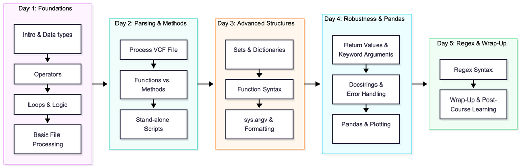

- Error handling using `try..except`, which helps you catch problems and prevent your program from crashing.
- Keyword arguments and positional arguments, which give you more control, readability, and flexibility when calling functions.
- Docstrings and comments, which provide clear documentation and make your code more understandable and maintainable.
- Pandas, a powerful and widely used library for working with tabular data.

### Day 5

- **Session 1**
  - Quiz: Review of Day 4
  - Lecture: Go through questions
  - Lecture: Introduction to regex
  - Ex1: Find the pattern using regex
- **Session 2**
  - Lecture: Regex in Python
  - Ex2: Regex using Python
  - PyQuiz 5.1
- **Session 3**
  - Lecture: Sum up
  - Presentation about NBIS
  - Ex3: Final exercise
- **Project time**

## Quiz: Review Day 4

Go to Canvas, `Modules -> Day 5 -> Review Day 4`

~15 minutes

### 1. What will be printed when you run the following code?

```python
def gc_count(seq):
    print(seq.count('G') + seq.count('C'))
    return 0

result = gc_count('ATGC')
print(result)
```

### 2. What is the difference between positional arguments and keyword arguments?

Keyword arguments can be given in any order, while positional arguments depend on the function's order

```python
def sum3(a, b, c):
    print(f"a={a}")
    print(f"b={b}")
    print(f"c={c}")
    return a+b+c
sum3(1, c=2, b=3)
```

#### Arguments can be used in both ways, with or without keyword, if there is no ambiguity

- When used with keyword, they are keyword arguments
- When used without keyword, they are positional arguments

### 3. What will be the output of the following code snippet?

```python
def add(x=0, y=1, z=0):
    return x + y + z
print(add(1, 2))
print(add(1, y=2, z=3))
print(add())
```

### 4. Why is it beneficial to use docstrings in functions?

- They provide explanations and details about the function for others reading your code. **Both `"""` and `'''` can be used for docstring**

```python
def add(x, y, z=0):
    """This function adds up three numbers, with the last one default to zero"""
    # Here we secretly increment x by 1
    x += 1
    return x + y + z
help(add)
```

### 5. How can you see the documentation of a Python library function in the console?

- Use help(library.function)

```python
help(print)
```

### 6. What will be printed when you run the following code?

```python
values = ['10', 'abc', '20']
total = 0
for v in values:
    try:
        total += int(v)
    except ValueError:
        print('Skipping', v)

print(total)
```

### 7. The user types 42 when the following code runs. What is the type of x?

```python
x = input('Give a number: ')
print(type(x))
```

### 8. If you want to filter rows in `df` where `age` is greater than 30, which command would you use?

- df[df['age'] > 30]

```python
import pandas as pd
df = pd.DataFrame({
    'Tree': [1, 1, 3, 4],
    'age': [25, 600, 700, 40],
    'height': [165.4, 175.3, 168.5, 180.6]
})
print(df)
df[df['age'] > 30]
```

### 9. Which command selects the rows where Tree is 1 and age is greater than 500?

```python
print(df)
df[[df['Tree'] == 1] | [df['age'] > 500]]
```

## Regular Expressions

- A regular expression (regex or regexp) is a sequence of characters that defines a search pattern.
- Use case: regular expressions are used in text processing for searching, matching, and manipulating strings

### Examples where regex can play a role

- Find variations in a protein or DNA sequence
  - `"MVR???A"`
  - `"ATG???TAG"`
- American/British spelling, endings and other variants:
  - salpeter, salpetre, saltpeter, nitre, niter or KNO3
  - hemaglobin, heamoglobin, hemaglobins, heamoglobin's
  - catalyze, catalyse, catalyzed...
- A pattern in a VCF or GTF file
  - a digit appearing after a tab

### Regex is not unique for Python and it is supported by

- most programming languages,
- text editors
- command line tools (e.g. `grep`, `sed`)
- search engines

```python
!grep "furniture.*sell" ../downloads/blocket_listings.txt
```

### A playground for regex with detailed explanations of your regex

https://regex101.com/

### Defining a search pattern

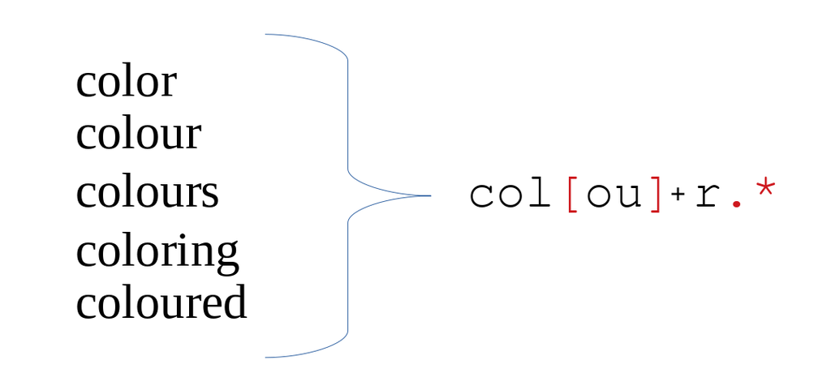

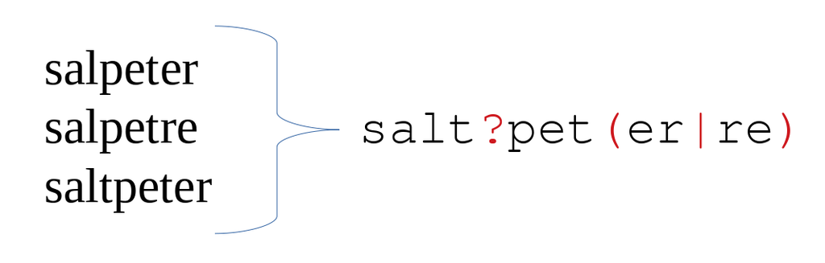

- `.` matches any character (once)
- `?` repeat previous pattern 0 or 1 times
- `*` repeat previous pattern 0 or more times
- `+` repeat previous pattern 1 or more times

```python
colou?r.* colou  [u]   colu
```

### More common operations - classes of characters

- `\w` matches any letter or number, and the underscore
- `\d` matches any digit
- `\D` matches any non-digit
- `\s` matches any whitespace (spaces, tabs, ...)
- `\S` matches any non-whitespace

### More common operations - classes of characters

- `\w` matches any letter or number, and the underscore

`\w+`

```
def functionName(arg1, arg2, arg3):
    final_value = 0
    # comments
    return final_value
```

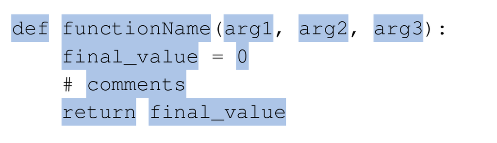

#### More common operations - classes of characters

- `\d` matches any digit

`\d+`

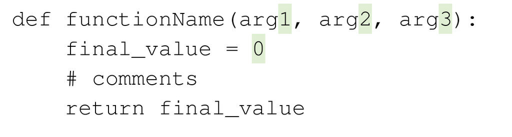

#### More common operations - classes of characters

- `\s` matches any whitespace (spaces, tabs, ...)

`\s+`

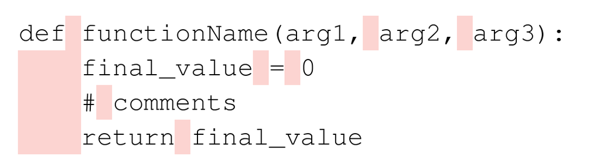

#### More common operations - classes of characters

- `[abc]` matches a single character defined in this set {a, b, c}
- `[^abc]` matches a single character that is **not** a, b or c
- `[a-z]` matches all letters between `a` and `z` (the english alphabet).
- `[a-z]+` matches any (lowercased) english word.

```
plaintext
Three cats and 11 dogs run fast across grass fields.
```

```python
# matches any single character not a letter and not a space.
[^a-zA-Z ]
```

### Some regular expressions are equivalent; choose the one that you prefer

| Shorthand | Equivalent Range | Description |
| --- | --- | --- |
| `\d` | `[0-9]` | Matches any digit (0-9). |
| `\D` | `[^0-9]` | Matches any non-digit character. |
| `\w` | `[a-zA-Z0-9_]` | Matches any word character (letters, numbers, and the underscore). |
| `\W` | `[^\w]` | Matches any non-word character (e.g., symbols, spaces). |
| `\s` | `[ \t\n\r\f\v]` | Matches any whitespace character (space, tab, newline, etc.). |
| `\S` | `[^\s]` | Matches any non-whitespace character. |

**Example - finding patterns in a VCF file** `1 920760 rs80259304 T C . PASS AA=T;AC=18;AN=120;DP=190;GP=1:930897;BN=131 GT:DP:CB 0/1:1:SM 0/0:4:SM...`

#### Find one record with at least one sample, that is, having genotype fields such as `0/0:1:SM` `0/0:4:SM`

- `"[01]/[01]"` (or `"\d/\d")`
- `\s\d/\d:`

```python
!grep -E "[01]/[01]" ../downloads/genotypes_small.vcf | head -n 1
```

**Example - finding patterns in vcf** `1 920760 rs80259304 T C . PASS AA=T;AC=18;AN=120;DP=190;GP=1:930897;BN=131 GT:DP:CB 0/1:1:SM 0/0:4/SM...`

- Find all lines containing more than one homozygous alternate sample (assuming all homozygous alternate are of the form 1/1, which might not be the case in general)

`... 1/1:... ... 1/1:... ...`

- `.*1/1.*1/1.*`
- `.*\s1/1:.*\s1/1:.*`

```python
sed -E ".*\s1/1:.*\s1/1:.*" ../downloads/genotypes_small.vcf  | wc -l
```

### Example from the project (with GTF file):

#### how many transcripts can the CFTR gene (ENSG00000001626) generate?

```python
!grep -E "transcript.*ENSG00000001626" ../assignment/data/Homo_sapiens.GRCh38.93.gtf  | wc -l
```

### Cheat sheet

- `.` matches any character (once)
- `?` repeat previous pattern 0 or 1 times
- `*` repeat previous pattern 0 or more times
- `+` repeat previous pattern 1 or more times
- `\w` matches any letter or number, and the underscore
- `\d` matches any digit
- `\D` matches any non-digit
- `\s` matches any whitespace (spaces, tabs, ...)
- `\S` matches any non-whitespace
- `[abc]` matches a single character defined in this set {a, b, c}
- `[^abc]` matches a single character that is **not** a, b or c
- `[a-z]` matches any (lowercased) letter from the english alphabet
- `.*` matches anything, but **not cross multiple lines**.

## Day 5, Exercise 1 (~30 min)

### Practicing regular expressions

- Canvas -> Modules -> Day 5 -> Exercise 1 - day 5

Start the exercise by running

**python retester.py**

in the `downloads` folder in a terminal

#### Take a break after the exercise (~10 min)

## Session 2

- How to use regex in Python
- Ex2: Regex using Python
- PyQuiz 5.1

### Regular expressions in Python

```python
import re
pattern = r"col[ou]+r.*"
text = "The colour of the wall is very vibrant,\
but the color of the sky is even more spectacular."
# Try to find a hit
result = re.search(pattern, text)
if result:
    print(result.group())
    # print(result.span())
    # print(result.span()[0])
    # print(result.start())
else:
    print("No match found")
```

`result.group()`: Return the string matched by the expression

`result.start()`: Return the starting position of the match

`result.end()`: Return the ending position of the match

`result.span()`: Return both (start, end)

## Raw string

```
pattern = r"col[ou]+r.*"
```

- A raw string is a Python string literal prefixed with the letter `r`.
- Highly recommended to use raw string `(r"...")` for regular expression patterns in Python.
- Raw strings simplify pattern writing by preventing Python from interpreting backslashes `\` as special escape sequences.

```python
text = "The colour of the wall is very vibrant, but the color of the sky is even more spectacular."
pattern = "\bthe\b" # \b matches the word boundary, try with and without r""
                    # without 'r', \b is interpreted as ASCII backspace \x08
result = re.search(pattern, text)
if result:
    print(result.group())
else:
    print("No match found")
```

```python
# How if we only want to search for the words "colour", "color"?
pattern = r"col[ou]+r.*"
text = "The colour of the wall is very vibrant, but the color of the sky is even more spectacular."
# pattern = r"col[ou]+r\b"
result = re.search(pattern, text)
if result:
    print(f"Found text: '{result.group()}'")
    print(result.span())
else:
    print("No match found")
```

### How to find all occurences of "color" variations?

```
re.findall
```

```python
text = "The colour of the wall is very vibrant, but the color of the sky is even more spectacular."
pattern = r"col[ou]+r\b"
result = re.findall(pattern, text)
print(result)
```

### How to find all occurences of "color" variations with their positions in the text?

```
re.finditer
```

```python
text = "The colour of the wall is very vibrant, but the color of the sky is even more spectacular."
pattern = r"col[ou]+r\b"

for result in re.finditer(pattern, text):
    print(f"Find word: {result.group()} at {result.span()}")
```

### re.compile

```python
text = "The colour of the wall is very vibrant, but the color of the sky is even more spectacular."
pattern = r"col[ou]+r\b"
p_find_colour = re.compile(pattern)
#print(type(p_find_colour))
p_find_colour.search(text)
# re.search(pattern, text)
# p_find_colour.findall("colur colour color")
```

```python
p_find_colour.findall(text)
```

```python
for result in p_find_colour.finditer(text):
    print(f"Find colour at the position {result.span()}, the word is '{result.group()}'")
```

### Benefits of using `re.compile`

- Improved performance - saves time by compiling the regex only once, especially when used in a loop
- Reusability - the compiled regex can be used multiple times
- Early error detection - syntax error of the pattern can be detected at the compiling stage instead of mixed with the other `re` functions

### Case insensitiveness

```python
# Remember, [a-z]+ matches any lower case English word
pattern = r'[a-z]+'
result = re.search(pattern, '123 ATGAAA 456')
if result:
    print(result)
else:
    print("No match found")
```

```python
pattern = r'[a-z]+'

result = re.search(pattern, '123 ATGAAA 456', flags=re.IGNORECASE)
if result:
    print(f"Found hit {result.group()} at the position {result.span()}")
else:
    print("No match found")
```

### How to find a full stop?

```python
text = "The first full stop is here: ."

result = re.search(r".", text)
print(f"Found {result.group()} at position {result.start()}")
```

```python
# Use the escape character \
result = re.search(r"\.", text)
print(f"Found {result.group()} at position {result.start()}")
```

### More operations

- `\` escaping a character, use the character as is
- `^` beginning of the string r"^abc"
- `$` end of string
- `|` boolean `or`

## Matching beginning and end of line

`^hello$`

```python
text = "hello   \nhello\n    hello"
# print(text)
result = re.search(r'^hello$', text, flags=re.MULTILINE)
if result:
    print(f"Find word '{result.group()}' at position {result.span()}")
else:
    print("No match found")
```

### Substitution

```python
text = "Do it   becuase   I say so,     not becuase you want!"
# Spell the word because correctly
re.sub(r'becuase', 'because', text)
print(text)
```

```python
text = re.sub(r'becuase', 'because', text)
print(text)
```

```python
# Remove additional spaces
re.sub(r'\s+', ' ', text)
```

### Example from Day 2 when lstrip() does not work as expected

```python
line = "AB:A:B should not be removed"
line.lstrip("AB:") # The chars argument is not a prefix
```

```python
line.removeprefix("AB:")
```

```python
newline = re.sub(r"^AB:", "", line)
print(newline)
```

### Overview

- Construct regular expressions

```
    p = re.compile()
```

- Searching

```
    p.search(text)
    re.search(pattern, text)
```

- Substitution

```
    p.sub(replacement, text)
```

**Typical code structure for text matching:**

```
pattern = re.compile(r"regex")
result = pattern.search('string goes here')

if result:
    print('Match found: ', result.group())
else:
    print('No match')
```

### Summary

- A powerful tool to search and modify text
- There is much more to read in the [docs](https://docs.python.org/3/library/re.html)
- Note: regex comes in different flavours. If you use it outside Python, there might be small variations in the syntax.

## Day 5, Exercise 2 (~30 min)

### Use regular expressions with Python

- Canvas -> Modules -> Day 5 -> Exercise 2 - day 5
- Do bonus exercise only when you are super interested in RegEx

#### Take a break after the exercise (~10 min)

#### PyQuiz 5.1 (~10 min)

## Lunch

# Sum up!

### Processing files - looping through the lines

```
with open('myfile.txt', 'r') as fh
    for line in fh:
        do_stuff(line)
```

```python
with open('myfile.txt', 'r', encoding='utf-8') as fh
    for line in fh:
        do_stuff(line)
```

### Store values

```
iterations = 0
information = []

with open('myfile.txt', 'r') as fh:
    for line in fh:
        iterations += 1
        information += do_stuff(line)
```

### Values

- Base types:

  ```
  str     "hello"
  int     5
  float   5.2
  bool    True
  ```

- Collections:

  ```
  list  ["a", "b", "c"]
  dict  {"a": "alligator", "b": "bear", "c": "cat"}
  tuple ("this", "that")
  set   {"drama", "sci-fi"}
  ```

### Assign values

```
iterations = 0
score      = 5.2
# variable = literal
```

#### Compare and membership

```
+, -, *,...   # mathematical
and, or, not  # logical
==, !=        # (in)equality
<, >, <=, >=  # comparison
in            # membership
```

### Showing the result: use `f-string`

```python
# Use f-string for print out result
value = 4
nextvalue = 1
nextvalue += value
print(f"nextvalue: {nextvalue}, value: {value}")
```

### Be aware of the order of logical operators

```python
x = 5
y = 7
z = 0

x > 4 or y == 7  and z > 1
```

```python
(x > 4 or y == 7) and z > 1
```

### Strings

Works like a list of characters

```python
mystr = "one"
```

```python
mystr += " two" # string concatnation
mystr
```

```python
len(mystr) # get the length
```

```python
"one" in mystr # in operator for substring matching
# mystr.find("one") # return index if find a hit
# mystr.index("one") # Identical to .find(), but handles failure differently
```

### String is immutable

```python
mystr = "one"
mystr[1] = "W"
```

```python
mystr = "one"
print(mystr)
mystr = "two"
print(mystr)
```

```python
mystr = "one"
print(f"mystr = {mystr}, address = {id(mystr)}")
mystr = "two"
print(f"mystr = {mystr}, address = {id(mystr)}")
```

### String manipulation

```
  s.strip()  # remove trailing white spaces

  s.split()  # split the line into columns

  s.upper(), s.lower()  # change the case
```

### Regular expressions help you find and replace strings

```
  p = re.compile(r'A.A.A')
  p.search(dna_seq)

  p = re.compile(r'T')
  rna_seq = p.sub('U', dna_seq)
```

```python
import re
# the greedy star (*)! Match as long as possible
re.search(r'p.*\sp', 'a python programmer writes python code').group()
```

```python
# To match the shortest possible string, use non-greedy quantifier *?
re.search(r'p.*?\sp', 'a python programmer writes python code').group()
```

### Collections

Can contain strings, integer, booleans...

- Most collections are mutable (except **tuple**): you can *add*, *remove*, *change* values
- Lists:

```
        mylist.append('value')
```

- Dicts:

```
        mydict['key'] = 'value'
```

- Sets:

```
        myset.add('value')
```

### Collections

- Test for membership:

```
        value in myobj
```

- Check size:

```
        len(myobj)
```

### Lists

- Ordered!

```
        mylist = [1, 8, 1, 2, 4]

        mylist.sort()
        mylist.reverse()
        mylist[2]
        mylist[-1]
        mylist[2:6]
```

```python
mylist = [1, 8, 1, 2, 4]
mylist
```

```python
mylist.sort()
print(mylist)
```

```python
mylist.reverse()
print(mylist)
```

```python
mylist[2]
```

```python
mylist[-1]
```

```python
mylist[2:]
```

### Dictionaries

- List of key value pairs

```
    mydict = {"a": "alligator", "b": "bear", "c": "cat"}
    counter = {"cats": 55, "dogs": 8}

    mydict["a"]
    mydict.keys()
    mydict.values()
    mydict.items() # get both keys and values
```

```python
counter = {'cats': 0, 'others': 0}
# counter = {}
for animal in ['zebra', 'cat', 'dog', 'cat']:
    if animal == 'cat':
        counter['cats'] += 1
    else:
        counter['others'] += 1

print(counter)
```

### Sets

- Bag of values
  - No order
  - No duplicates
  - Fast membership checks
  - Logical set operations (union, difference, intersection...)

```
    myset = {"drama", "sci-fi"}

    myset.add("comedy")

    myset.remove("drama")
```

```python
set1 = set(["1", "2", "3", "4", "5"])
set1
```

```python
set1.add("1")
set1
```

```python
set2 = set(["3", "6"])
set1.intersection(set2)
```

```python
set1.union(set2)
```

```python
set1.difference(set2)
```

### Tuples

- A group (usually two) of values that belong together

```
        tup = (max_length, sequence)
```

- An ordered sequence (like lists)

```
        length = tup[0]  # get content at index 0
```

- Immutable

```python
tup = (2, 'xy')
tup[0]
# type(tuple((list(tup)))) # tuple and list can be converted
```

```python
tup[0] = 2
```

### Tuples in functions

```
def find_longest_seq(file):
    # some code here...
    return length, sequence
```

```python
def find_longest_seq(file):
    length = 10
    sequence = "AAAAATTTTT"
    return length, sequence

answer = find_longest_seq("dummyfile") # return as a tuple
print(type(answer))
# _, sequence = find_longest_seq("dummyfile") # return as two variables
# print(sequence)
```

### Deciding what to do with if else statement

```python
count = 8
if count > 10:
    print('big')
elif count > 5:
    print('medium')
else:
    print('small')
```

#### Deciding what to do - if statement

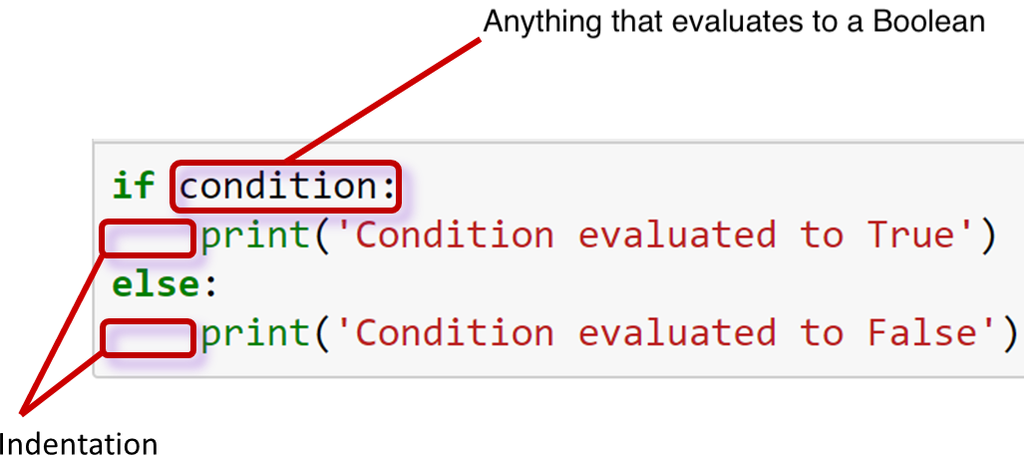

#### `if x:` is equvalent to `if bool(x):`

```python
if [1,4,6]:
    print("yes")
```

### Program flow - for loops

```python
information = []
with open('myfile.txt', 'r') as fh
    for line in fh:
        if is_comment(line):
            use_comment(line)
        else:
            information.append(read_data(line)) # read_data return a list
```

### Program flow - while loops

```python
information = []
with open('myfile.txt', 'r') as fh:
    # Read the first line
    line = fh.readline()

    # Continue to read lines until an empty string is returned
    while line:
        information.append(read_data(line)) # read_data return a list
        line = file.readline()  # Read the next line
```

### Different types of loops

**`For` loop**

is a control flow statement that performs operations over a known amount of steps.

**`While` loop**

is a control flow statement that allows code to be executed repeatedly based on a given Boolean condition.

**Which one to use?**

`For` loops - standard for iterations over lists and other iterable objects

`While` loops - more flexible and can iterate an unspecified number of times

```python
# For loop example
# You know the number of iterations before hand
user_input = "thank god it's friday"
for letter in user_input:
    print(letter.upper())
```

```python
# While loop example
# The number of iterations is unknown before hand
key = ""
max_try = 3
cnt = 0
TARGET_KEY = "python2026"
while key != TARGET_KEY:
    key = input("Enter your key: ")
    cnt += 1
    if cnt > max_try:
        print("WARNING!! Too many failures!")
        break
    if key == TARGET_KEY:
        print("Correct key!")
```

### Controlling loops

- `break` - stop the loop
- `continue` - go on to the next iteration

```python
# example for break
user_input = "thank god it's friday"
for letter in user_input:
    if letter == 'd':
        break
    print(letter.upper())
```

```python
# example for continue
user_input = "thank god it's friday"
for letter in user_input:
    if letter == ' ' or letter == '\'':  # Skip spaces and apostrophes
        continue
    print(letter.upper())
```

**Watch out!**

```python
# DON'T RUN THIS
i = 0
-while i < 10:
    print(user_input[i])
```

While loops may be infinite!

### File Input/Output

- In: Read from files

  ```
  with open(filename, 'r') as fh:
     for line in fh:
         do_stuff(line)
  ```

  Read information from command line: `sys.argv[1:]`
- Out: Write to files:

  ```
  with open(filename, 'w') as fh:
     fh.write(text)
  ```

- Printing:

  ```
  print('my_information')
  ```

### Input/Output

Open files should be closed:

```
      fh.close()
```

or use the `with` clause

```
    with open(filename, "r") as fh:
        do_something
```

### Code structure

- Functions (unit)
- Modules (the file)
- Packages (the folder)
- Libraries (the large collection)

#### Functions

- A named piece of code that performs a certain task.

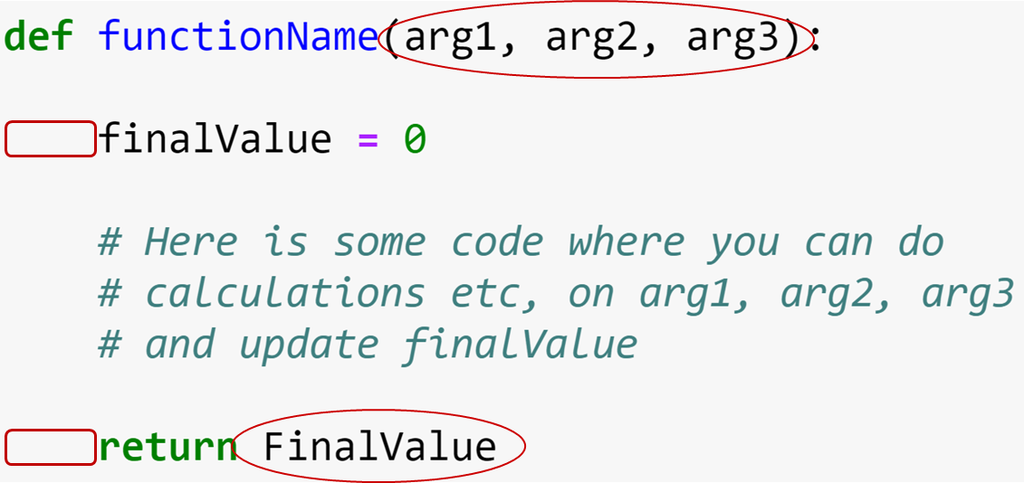

- Is given a number of input arguments
  - to be used within the function body
- Returns a result (maybe `None`)

### Functions - arguments

```
    def prettyprinter(name, value, delim=":", end=None):
        out = "The " + name + " is " + delim + " " + value
        if end:
            out += end
        return out
```

- used to set default values (often `None`)
- can be skipped in function calls, then the arguments are positional
- improve readability when keys are used

### Using your code

Any longer pieces of code that have been used and will be re-used should be saved

- Save it as a file `mycode.py`
- To run it: `python3 mycode.py` or `python mycode.py`
- Import it: `import mycode`

### Documentation and comments

```
""" This is a doc-string explaining what the purpose of this function/module is """
```

```
# This is a comment that helps understanding the code
```

- Comments *will* help you
- Undocumented code rarely gets used
- Try to keep your code readable: use informative variable and function names

### Why programming?

Endless possibilities!

- reverse complement DNA
- custom filtering of VCF files
- plotting of results
- dealing with excel files

### Why programming?

- Computers are fast
- Computers don't get bored
- Computers don't get sloppy
- Create reproducable results
  - for you and for others to use
- Extract large amount of information

### Type hinting: popular for modern Python coding

```python
age: int = 30
name: str = "Bob"

def show_new_age(age: int, name: str) -> int:
    # 'age' is expected to be an integer
    # 'name' is expected to be a string
    # The function is expected to return an integer
    new_age: int = age + 10
    print(f"New age of {name} is {new_age}")
    return new_age

show_new_age(age, name)
```

- Type hinting improve the documentation and readability
- With proper tools and IDE, type hinting helps early detection of errors and debugging

```python
age: int = 30.0
name: str = "Bob"
print(type(age))
```

#### Type hinting does not change how Python interprets your code

### Why learning programming

- AI agents are already very powerful and keep evolving rapidly
- AI still makes mistakes
- In research, the answer or expected result format is usually unknown beforehand
- You know the basics - don't be afraid to try, it's the only way to learn
- You will get faster

### Final advice

- Getting help
  - Ask colleauges
  - Try speak out your problem
  - Search the web
  - Ask AI and use AI (e.g. Claude, Gemini, ChatGPT, Muse), but with caution.
  - Don't spend too much time on memorizing function and library names etc unless it's your hobby
  - [NBIS drop-ins](https://nbis.se/get-support/talk-to-us)

### Now you know Python!

🎉

Well done!

### You will get a certificate after the course

#### NBIS presentation

**[Google Form for anonymous evaluation](https://forms.gle/Sr8BXTKNBDiicfKf7)**

#### Just a small exercise to finish the day and have fun!

Canvas -> Module -> Day 5 -> Exercise 3 - day 5

### Exercise 3

```python
!cp ../downloads/checker.py .
# !copy ../downloads/checker.py . # on Windows probabaly
```

```python
import checker
```

```python
checker.check()
```

```python
name = "Shu"
checker.check_name(name)
```